# R04 Paneldata

Plot and Understand Data over Time

Marco Kühne

25 April 2022

# Instructions

Please create a R markdown script and name it `R04_name.Rmd` replacing `name` by your name. Follow the structure of this document. Start each section with the appropriate heading by using a hashtag as first symbol. When you are done, knit your document in order to create a HTML file. Name it `R04_name.html` replacing name by your name.

The final `R04_name.html` document is supposed to show code and its result. Optimally, it should hide warnings and messages. Make it clean and concise. Upload `R04_name.Rmd` and `R04_name.html`.

# Load Data

```r
library(tidyverse)
library(haven)

soep <- read_dta("https://github.com/MarcoKuehne/seminars_in_applied_economics/blob/main/Data/soep_lebensz_en.dta?raw=true")
```

# Average Satisfaction per Year (3 pt)

Average life satisfaction in Germany appears to be stable. Please replicate the following graph. Start from `soep` data, `group_by()` year and `summarize()` the mean of satisfaction. Pipe the result in a `ggplot()` command. Years go on the x-axis, mean life satisfaction on the y-axis. Use a `geom_line()` and a `geom_point()` layer. Scale y-axis from 0 to 10. Label everything appropriately.

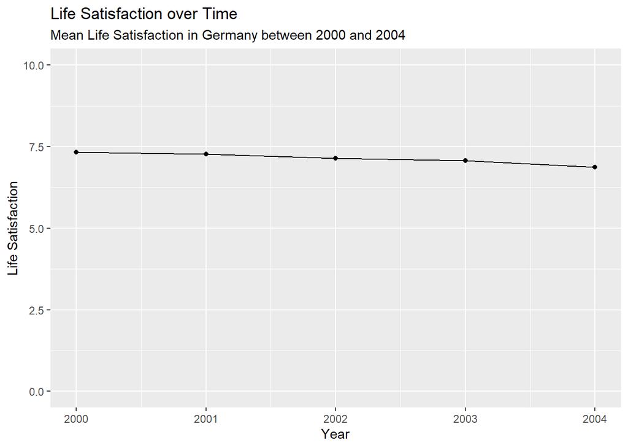

# Individual Satisfaction per Year (2 pt)

Copy and run the following code to define the `sample_n_groups()` function.

```r
sample_n_groups = function(grouped_df, size, replace = FALSE, weight=NULL) {
  grp_var <- grouped_df %>%
    groups %>%
    unlist %>%
    as.character
  random_grp <- grouped_df %>%
    summarise() %>%
    sample_n(size, replace, weight) %>%
    mutate(unique_id = 1:NROW(.))
  grouped_df %>%
    right_join(random_grp, by=grp_var) %>%
    group_by_(grp_var)
}
```

Set 2 as a seed using `set.seed()` command. Start with `soep` data and `group_by()` person. From personal observations sample 5 (pseudo-)random people using the new `sample_n_groups()` function. Pipe this into another `ggplot()` call. Use `color=as_factor(id)` as an aesthetic. Adjust the scale of y-axis and labels. The result should look exactly like this:

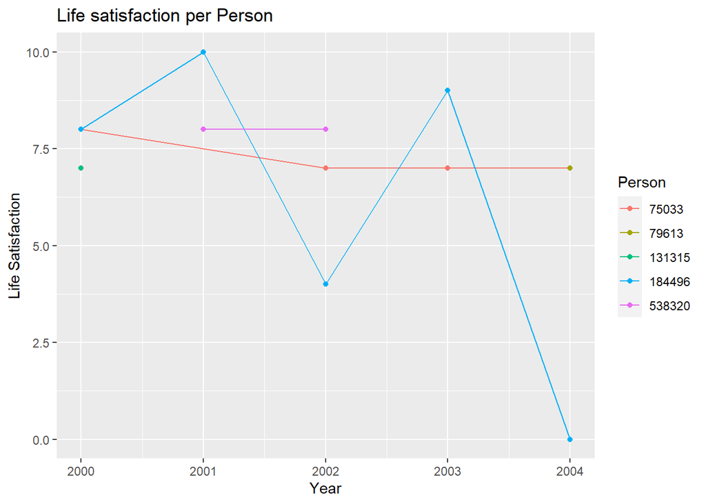

# Within and Between Variation (3 pt)

The following table shows **minimal panel data** and its between and within variation. Three people are observed in three periods each (no missings). The panel data is **balanced** (all individuals are observed in all years, there are no gaps).

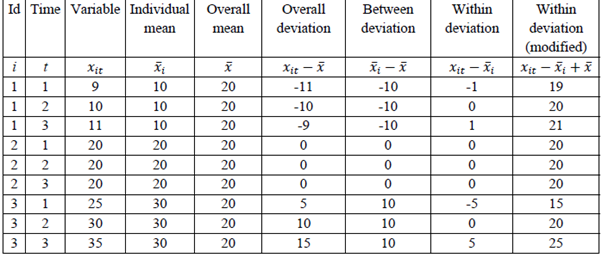

Table 1: Minimal Working Example for Within and Between Variation ([Source](http://rizaudinsahlan.blogspot.com/2016/06/within-and-between-variation-in-panel.html)).

Please select two individuals from `soep` with `id` equal to 293973 and 317284. Recalculate all columns for those two individuals (each 0.5 pt). All necessary formulas are provided in the table. Hint: You may use tidyverse verbs `filter`, `select`, `group_by`, `ungroup` and `mutate`. In a long pipe of commands you can turn the group mode on and off, i.e. `group_by(id)`, calculate something on the group level, `ungroup()`, calculate something else on all data. Your result should be:

Understanding between and within variation.

| id | year | satisf_org | Individual_Mean | Overall_Mean | Overall_Deviation | Between | Within | Within_alt |
| --- | --- | --- | --- | --- | --- | --- | --- | --- |
| 293973 | 2000 | 10 | 6.67 | 8.62 | 1.38 | -1.95 | 3.33 | 11.95 |
| 293973 | 2001 | 0 | 6.67 | 8.62 | -8.62 | -1.95 | -6.67 | 1.95 |
| 293973 | 2002 | 10 | 6.67 | 8.62 | 1.38 | -1.95 | 3.33 | 11.95 |
| 317284 | 2000 | 10 | 9.80 | 8.62 | 1.38 | 1.18 | 0.20 | 8.82 |
| 317284 | 2001 | 10 | 9.80 | 8.62 | 1.38 | 1.18 | 0.20 | 8.82 |
| 317284 | 2002 | 9 | 9.80 | 8.62 | 0.38 | 1.18 | -0.80 | 7.82 |
| 317284 | 2003 | 10 | 9.80 | 8.62 | 1.38 | 1.18 | 0.20 | 8.82 |
| 317284 | 2004 | 10 | 9.80 | 8.62 | 1.38 | 1.18 | 0.20 | 8.82 |

# T-hrowback on t-Tests (2 pt)

Remember the two kinds of t-Tests:

- unpaired two sample t-Test
- paired two sample t-Test (= repeated t-Test or *panel t-Test*)

```r
before_after <- soep %>%
  filter(complete.cases(.)) %>% # use complete cases
  filter(year == 2000 | year == 2004) %>% # only use year 2000 or 2004
  group_by(id) %>% # look at id groups
  filter(n() == 2)  # only keep groups with exactly two observations/rows
```

For `before_after` data,

- Please run a `t.test()` on variables with `paired=TRUE` that works and make sense (0.5 pt).
- Please run a `t.test()` on variables with `paired=TRUE` that works and does not make sense (0.5 pt).
- Please run a `t.test()` on variables with `paired=FALSE` that works and does not make sense (0.5 pt).
- Please write down a `t.test()` on variables with `paired=FALSE` that does not work (0.5 pt). Put the non-working command in comments (otherwise the document cannot be knitted).

Please put each `t.test()` in a separate code chunk.